# Приходят в бар физтех и студент ВШЭ

**Ну и сделали задание по ML короче**

*Дорогой студент, в этом небольшом пособии студент второго курса МФТИ попытается как-нибудь решить задачу [по предсказанию стоимости недвижимости](https://www.notion.so/480aa51c26eb4a1ba116ac74fb963495). Не судите строго, ведь полноценного курса анализа данных у нас пока не было, так что используя минимальные навыки я попытаюсь набить хоть какой-нибудь score модельки.*

*Это пособие попытается быть научно-развлекательным и введет вас в курс дела ML, если получится.*

**Постановка задачи:** дан массив данных о продажах квартир с информацией о квартирах и известными ценами продаж. Цель - построить модель, которая по этим данным предскажет научится предсказывать цену продажи. Т.е. если придет новая квартира, без известной цены, то ей можно будет предсказать примерную цену, по которой её можно продавать. Задача предсказания числа по некоторому вектору(списку) признаков называется **задачей регрессии**.

Скачиваем и импортим всякие библиотечки (могут возникнуть проблемы с их отсутствием на вашем локальном компутере - используйте "python3 -m pip install numpy" в консоли или обращайтесь к специалисту)

```python
import numpy as np
import pandas as pd
import matplotlib.pyplot as plt
import seaborn as sns
import scipy

sns.set(style='whitegrid', font_scale=1.3, palette='Set2')
%matplotlib inline
```

Кладём наш файл с данными в одну папку с файлом с кодом. Посмотрим на его содержимое:

```python
data = pd.read_csv('realty_train.csv')
data.head()
```

|  | Unnamed: 0 | title | price | pricePerArea | priceValue | pricePerAreaValue | details | address | location | galleryImagesCount | ... | adminDistrictId | districtId | metroId | roomsOrdinal | isStudio | isFreePlan | apartmentSaleType | developmentId | developmentName | roadId |
| --- | --- | --- | --- | --- | --- | --- | --- | --- | --- | --- | --- | --- | --- | --- | --- | --- | --- | --- | --- | --- | --- |
| 0 | 60466 | Квартира-студия, 26.8 м², 2/21 эт. | 10 376 413 ₽ | 387 180 ₽ за м² | 10376413 | 387180 | 26.8 м² | ш. Очаковское, корп. 3.1 | {'longitude': 37.45927, 'latitude': 55.69376} | 17 | ... | 10.0 | 522.0 | NaN | NaN | True | False | New | 1.057023e+09 | ЖК «Vangarden» | NaN |
| 1 | 52761 | 3-комн. квартира, 89.8 м², 8/9 эт. | 35 000 000 ₽ | 389 755 ₽ за м² | 35000000 | 389755 | 89.8 м² | пр-т Андропова, стр. Б | {'longitude': 37.65629, 'latitude': 55.68825} | 15 | ... | 8.0 | 529.0 | 320.0 | 3.0 | False | False | New | 1.015418e+09 | Жилой остров «Nagatino i-Land» | NaN |
| 2 | 15103 | 1-комн. квартира, 30.1 м², 3/5 эт. | 9 600 000 ₽ | 318 937 ₽ за м² | 9600000 | 318937 | 30.1 м² | Москва, Боровский проезд, 20 | {'longitude': 37.383444, 'latitude': 55.653401} | 7 | ... | 10.0 | 622.0 | NaN | 1.0 | False | False | Resale | NaN | NaN | NaN |
| 3 | 519 | 3-комн. квартира, 80.2 м², 27/33 эт. | 21 543 625 ₽ | 268 624 ₽ за м² | 21543625 | 268624 | 80.2 м² | б-р Кронштадтский, д. 14 | {'longitude': 37.49631, 'latitude': 55.84093} | 10 | ... | 4.0 | 577.0 | 38.0 | 3.0 | False | False | New | 1.034179e+09 | ЖК «Кронштадтский 14» | NaN |
| 4 | 83530 | 3-комн. квартира, 74.8 м², 13/33 эт. | 17 842 790 ₽ | 238 540 ₽ за м² | 17842790 | 238540 | 74.8 м² | Кавказский б-р, корп. 1.1-1.4 | {'longitude': 37.64052, 'latitude': 55.62784} | 13 | ... | 8.0 | 592.0 | 52.0 | 3.0 | False | False | New | 1.055124e+09 | ЖК «Кавказский бульвар 51» | NaN |

5 rows × 40 columns

Оценим размер данных (55тыщ это enough)

```python
data.info()
```

```
<class 'pandas.core.frame.DataFrame'>
RangeIndex: 55345 entries, 0 to 55344
Data columns (total 40 columns):
 #   Column                      Non-Null Count  Dtype
---  ------                      --------------  -----
 0   Unnamed: 0                  55345 non-null  int64
 1   title                       55345 non-null  object
 2   price                       55345 non-null  object
 3   pricePerArea                55345 non-null  object
 4   priceValue                  55345 non-null  int64
 5   pricePerAreaValue           55345 non-null  int64
 6   details                     55345 non-null  object
 7   address                     55345 non-null  object
 8   location                    55345 non-null  object
 9   galleryImagesCount          55345 non-null  int64
```

[output cut: 32 more lines]

Далее, как это принято - разделим наши данные на 2 или 3 части. Я выберу подход с 3мя частями - **тренировочная, валидационная и тестовые выборки**. На тренировочной мы будем обучать наши модели. На валидационной - подгонять какие-то гиперпараметры (у разных моделей - разного рода гиперпараметры: для деревьев - глубина, для регрессий - некоторый коэффициент регуляризации), которые не обучаются сами собой. На тестовой будем проверять результат и сравнивать модели.

```python
from sklearn.model_selection import train_test_split

train_ratio = 0.6 # 60% выборки выделим на обучение, т.к. это самая важная часть
val_ratio = 0.2
test_ratio = 0.2

train, test = train_test_split(data, test_size=test_ratio)
train, val = train_test_split(train, test_size=val_ratio/(train_ratio + val_ratio))

train.shape, val.shape, test.shape
```

```
((33207, 40), (11069, 40), (11069, 40))
```

В [задании](https://www.notion.so/480aa51c26eb4a1ba116ac74fb963495) четко попросили ориентироваться на список переменных, описанный там, а не на колонки данного датасета. Поэтому сформируем список категориальных колонок (столбцы, где может быть всего несколько значений) и вещественные исходя из списка оттуда. Отдельно выделим целевой признак.

**P.S. Очень неприятным моментом является признак местоположения**: использовать местоположение (ширина и долгота) не представляется возможным в контексте нашей необъятной родины (в рамках одного региона или маленькой страны это было бы полезно, но в рамках большой страны ширина и долгота вряд ли что-то покажут).

Можно взять признак cityId в качестве категориального (ибо такова его природа), поскольку часто цена квартиры определяется городом (к примеру Москва и Лобня - большая разница), а не регионом(признак regionId) (оба Московская область - опустим что Москва из другого региона).

Можно взять признак - ближайшая станция метро (station). Он достаточно неплохо описывает цену даже в рамках конкретного города, и является категориальным по своей природе. Попробуем его, несмотря на то, что у него много возможных значений (суммарно наберется не меньше 400 станций по России).

Попробуем cityId, и посмотрим что получится.

**P.P.S. попробовав, я заметили что количество колонок осталось около 30 и удивился, что количество городов такое небольшое (категориальный признак с N категориями - раскрывается в N** (на самом деле в N-1 чтобы избежать линейной зависимости) **колонок с 0-1 значениями. Оказалось что город-то всего 1 (с id = 3584). Москва судя по всему.** Вот пруф:

```python
train['cityId'].value_counts()
```

```
3584    33207
Name: cityId, dtype: int64
```

**Значит наша задача лежит в предсказании цены по Москве! Это меняет дело - ведь широта и долгота начинают играть ключевую роль. Как и станция метро, собственно.** Выберем в качетсве критерия широту и долготу и положим их вещественными признаками, чтобы не плодить 200 признаков (измерений) с 0-1 значениями, отвечающими за метро.

```python
categorial_features = ['hasVideos', 'isReported', 'isVerifiedProAgency', 'isShownLowQualityIndicator', 'isPremium', 'rooms', 'itemType', 'propertyType', 'isStudio', 'isFreePlan']
real_features = ['galleryImagesCount', 'floorInt', 'floorAreaCalculated', 'longitude', 'latitude']
target_feature = 'priceValue'
```

Давайте рассмотрим наши данные и напишем функцию, которая приводит выборку к читаемому формату (всё что возможно - переведем в циферки), отбрасывает мусор, а также отделяет целевой признак от других признаков.

```python
from sklearn.preprocessing import OneHotEncoder
import copy
import json

def drop_outliers(data, real_features):
    return data[(np.abs(scipy.stats.zscore(data[real_features])) < 3).all(axis=1)]

def prepare(data, encoder, first_use=False, drop=False):
    d = copy.deepcopy(data)

    # Немножко поприкалываемся, чтобы вытащить из единого столбца location - два столбца с широтой и долготой
    d['location'] = d['location'].apply(eval)
    for name in ['longitude', 'latitude']:
        d[name] = d['location'].apply(lambda x: x.get(name))

    if drop:
        d = drop_outliers(d, real_features)
    if first_use:
        train_cat = encoder.fit_transform(d[categorial_features])
    else:
        train_cat = encoder.transform(d[categorial_features])

    train = np.hstack([d[real_features], train_cat])
    cat_labels = [[title+", "+str(x) for x in l] for l, title in zip(encoder.categories_, encoder.feature_names_in_)]
    labels = copy.deepcopy(real_features)
    for x in cat_labels:
        labels += x[1:] # list concatenation
    return train, np.array(d[target_feature]), labels

encoder = OneHotEncoder(sparse=False, drop='first')
input_train, target_train, labels = prepare(train, encoder, first_use=True, drop=True) # return numpy arrays btw
input_val, target_val, labels = prepare(val, encoder)
input_test, target_test, labels = prepare(test, encoder)
len(labels), input_test.shape[1], labels
```

```
(19,
 19,
 ['galleryImagesCount',
  'floorInt',
  'floorAreaCalculated',
  'longitude',
  'latitude',
  'hasVideos, True',
  'isVerifiedProAgency, True',
  'isPremium, True',
  'rooms, 2',
  'rooms, 3',
  'rooms, 4',
  'rooms, 5',
  'rooms, 7',
  'rooms, 8',
  'rooms, 9',
  'rooms, Своб. планировка',
  'rooms, Студия',
  'isStudio, True',
  'isFreePlan, True'])
```

Получилось 19 итоговых колонок, по которым мы будем предсказывать 20ую - цену.

К этому моменту мы имеем так называемые X и y. X - вектор признаков, y - целевая величина. Наша цель - 'построить' функцию f(X), которая возвращает $\widehat{y}$ - некоторое предсказание величины y. Как понять, что функция хороша? Величина $|y - \widehat{y}|$ должна быть небольшой, например. Способ оценивать хорошесть функции f (а функцию называют моделью) - метрика. Метрики бывают разные (для разных задач тем более), но нам интересны три следующих (описание вот):

$MAE = \frac{1}{n} \sum^n_{i=1} |f(X_i) - y_i|$ - средняя ошибка;

$MAPE = 100 * \frac{1}{n} \sum^n_{i=1} |\frac{f(X_i) - y_i}{y_i}|$ - средний процент ошибки;

$RMSE = \sqrt{\frac{1}{n} \sum^n_{i=1} (f(X_i) - y_i)^2}$ - средняя квадратичная оценка;

Эти метрики мы будем считать на тестовой выборки (как бы тестировать модель). Мы сперва притворимся, что не знаем итоговую цену, предскажем её, а затем сравним с настоящей ценой.

Подготовим функции, которые помогут нам оценивать эффективность модели.

```python
from sklearn import metrics
def mean_absolute_percentage_error(y_true, y_pred):
    return 100 * (np.abs((y_true - y_pred) / y_true)).mean()

def print_measurements(true_, preds_):
    print(f"MAE: {metrics.mean_absolute_error(true_, preds_)}")
    print(f"MAPE: {mean_absolute_percentage_error(true_, preds_)}")
    print(f"RMSE: {metrics.mean_squared_error(true_, preds_) ** 0.5}")
```

Кажется все приготовления сделаны, данные очищены и подготовлены, метрики выбраны. Дело на самом деле за малым - выбрать модель, функцию f, которая по вектору $X_i$ предскажет нам $\widehat{y_i}$, да так, чтобы разность $|y_i - \widehat{y_i}|$ была чаще всего (или в среднем, вернее сказать) небольшой. Вот так выглядит некоторый $X_0$ (описание колонок есть парой слайдов выше):

```python
input_test[0]
```

```
array([20.     , 11.     , 28.3    , 37.44462, 55.59195,  1.     ,
        0.     ,  0.     ,  0.     ,  0.     ,  0.     ,  0.     ,
        0.     ,  0.     ,  0.     ,  0.     ,  1.     ,  1.     ,
        0.     ])
```

1) Самой простой моделью является **линейная регрессия**. Т.е. такая функция, которая линейна по каждому признаку. Примером такой функции можно назвать $f(x_1, x_2, ..., x_{19}) = x_1 + x_2 + ... + x_{19} + 4$. На деле подбираются не единичные коэффициенты, а какой-то оптимальный вектор из 20 коэффициентов. Однако тут надо понимать, что в нашей ситуации (когда ширина и долгота в Москве играют важную роль, и по ним наша цена явно нелинейна (ну т.е. нет некоторого направления вдоль которого растёт цена; цена растет по мере приближения к центру, а потом уменьшается)). А значит линейные модели дадут не слишком крутой результат, имхо.

2) Следующим вариантом модели можно взять **решающие деревья**. Это такая конечная структура, что-то в стиле дерева условных операторов, которая после прохождения нескольких условий (Example: rooms < 5, isPremium = True, rooms >= 3, следовательно предсказать price = 1 миллион). Такая модель достаточно интерпретируема для человека, т.е. он может понять как моделью принималось то или иное значение. Деревья бывают разной глубины (выше в примере дерево глубины 3) и у них случается переобучение иногда (т.е. если построить дерево глубины 1000, типа суперумный мегамозг с кучей ветвлений), то оно будет офигенно решать задачи из обучающей выборки, но когда к нему придет задача из тестовой выборки, то дерево не разберется с ней, потому что идеально подстроилось под обучающее. Поэтому глубина дерева - гиперпараметр, который подбирают отдельно, на валидационной выборке.

3) Есть ещё один вариант - **нейронная сеть**. Это такой же детерминированный алгоритм предсказания $\widehat{y}$, как и линейная регрессия. Тоже какие-то коэффициентики, умножения и сложения, только немного сложнее. С некоторой точки зрения, нейронная сеть - это комбинация многих линейных регрессий, с некоторой приправой (функция активации), которая позволяет изменять линейные зависимости на более сложные и делать конфетку.

Есть ещё много вариантов, но мы остановимся на сравнении линейной регрессии и нейронной сети (чтобы доказать что нейронка справится лучше). Если останется время, то бахнем и решающие деревья. Сравнивать будем с помощью метрик выше на тестовой выборке, если вы помните.

### Глава 1. Линейная регрессия.

```python
from sklearn.linear_model import LinearRegression

linear_model = LinearRegression(fit_intercept=True)
linear_model.fit(input_train, target_train);
```

```python
print_measurements(target_test, linear_model.predict(input_test))
```

```
MAE: 5359019.244104155
MAPE: 32.56172061775772
RMSE: 10789456.037552081
```

### Глава 2. Нейронная сеть

Я подумал что грех не показать картиночку двухслойной нейронной сети, которая на вход принимает одно число и на выходе даёт одно.

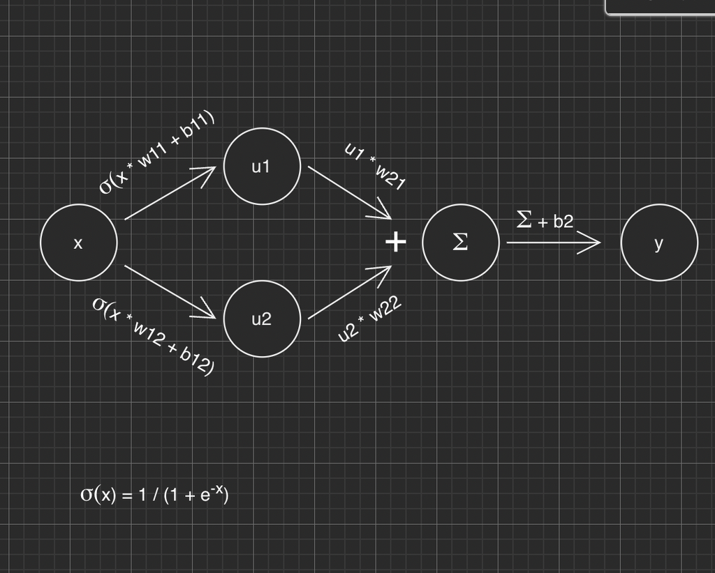

```python
from IPython.display import Image
Image("picture.png")
```

Вот эта вот сигма (функция внизу) - эта функция активации, которая используется чтобы круто комбинировать линейные зависимости (вы можете видеть, что сигма применятеся к линейным преобразованиям на стрелочках x -> $u_1$ и x -> $u_2$). Если бы не было функции активации, то вся наша нейронная сеть превратилась бы в одну большую линейную модель. Модель двухслойная, потому что есть слой на котором есть $u_1$ и $u_2$, а затем есть слой с $\sum$. Второй слой устроен попроще, там не используется функция активации и вообще одна вершина. К нейронным сетям ещё добавляют прикольные слои, на которых преобразовывают данные (например все данные приводятся в [0, 1] промежуток).

```python
import sys
!{sys.executable} -m pip install torch

import torch
from torch import nn
import torch.nn.functional as F
from IPython.display import clear_output
```

Инициализируем модель и подпиливаем всё в стиль torch.

```python
neural_model = nn.Sequential(  # собираем модули в последовательность
#    nn.Linear(in_features=19, out_features=19),  # кол-во признаков во входном слое 19, в выходном тоже 19
#    nn.Sigmoid(),  # та же ф-ция активации, что и раньше, только из pytorch
    nn.Linear(in_features=19, out_features=1)  # кол-во признаков во входном слое 19, в выходном тоже 1
)

x = torch.tensor(input_train, dtype=torch.float32)
y = torch.tensor(target_train, dtype=torch.float32)

x_new = x
y_new = y.reshape(-1, 1)
```

Инициализируем параметры модели (которые будут обучаться)

```python
def init_weights(m):
    if isinstance(m, nn.Linear):
        torch.nn.init.xavier_uniform(m.weight)
        m.bias.data.fill_(0.01)

neural_model.apply(init_weights);
```

Тренируем модель

```python
def show_progress(x, y, y_pred, loss):
    y_pred = y_pred.detach()
    loss = loss.item()
    clear_output(wait=True)
    print(f"MAE = {loss:.3f}")

optimizer = torch.optim.SGD(neural_model.parameters(), lr=500)
optim_func = nn.L1Loss()

num_iter = 10000

for i in range(num_iter):

    y_pred =  neural_model(x_new)

    loss = optim_func(y_pred, y_new)

    loss.backward()

    optimizer.step()

    optimizer.zero_grad()

    if (i + 1) % 5 == 0:
        show_progress(x_new, y_new, y_pred, loss)
        print(i)
```

```
MAE = 4889063.500
9999
```

```python
x = torch.tensor(input_test, dtype=torch.float32)
y = torch.tensor(target_test, dtype=torch.float32)

x_new = x
y_new = y.reshape(-1, 1)

print_measurements(target_test, neural_model(x_new)[:,0].cpu().detach().numpy())
```

```
MAE: 5421472.1966415215
MAPE: 26.970554098461065
RMSE: 10152797.491525399
```

**Вывод:** ну вот мы и закончили. ВСеМ ВнИМаНиЕ! Спасибо за внимание.

А если серьезно, то вот что получилось - линейная модель ошибается в среднем на 30% от правильной цены. Нейронная сеть работает чуть лучше, но очевидно можно сильно лучше. Стоит подшаманить слои при инициализации модели.